# Epidemiological Methods I

Jacob Simmering, PhD

February 22, 2018

## Objectives

- Describe the major methods and approaches used in observational data analysis
- Describe how these methods differ from both experimental and quasi-experimental approaches
- Describe when to use a cohort study, a case-control study and other designs
- Describe the advantages and disadvantages of each design

## Causal Effect Estimation

A causal effect of a factor is typically what we are interested in understanding, regardless of whether we are using experimental or non-experimental methods. The causal effect may be the effect of a risk factor such as an exposure or the effect of a treatment decision. For instance, we may be interested in the effect of taking ibuprofen on a headache 60 minutes after taking the pill. The causal effect of ibuprofen is the difference after 60 minutes between the two states - taking ($T = 1$) and not taking ($T = 0$) the medication. Let’s say the intensity of the headache is given by the variable $H$ and then we can express the causal effect as the $E(H | T = 1) - E(H | T = 0)$ (note the $E()$ is the expected value function, you can think of it like an average).

The “fundamental problem of causal inference” is that we cannot observe both $E(H | T = 1)$ and $E(H | T = 0)$ on the same person, at least not for the same headache. A subject must either be in the treatment group or in the non-treatment group for a given headache and so we must rely statistical methods to estimate this effect.

However, when using these methods, we must be concerned with the potential for confounding. There may be another variable, say amount of sleep the prior night denoted as $S$, that varies between subjects and is related to headache intensity.

In a random assignment framework, such as used in many expirmental approaches, or a quasi-random assignment, as in the quasi-expirmental methods, we are able to ignore the effect of $S$ on $H$ because it is balanced by virtue of the random assignment. Any potential relationship between $S$ and $H$ is broken by virtue of the random assignment.

You may recruit a sample of people with headaches and assign half to take ibuprofen and the other half to a placebo. Suppose that a typical headache has a “intensity score” of 50 and the score increases or decreases by 5 for each additional hour slept more than/less than 7 hours the prior night. If a patient takes medication for the headache, the intensity decreases by 5. Using these assumptions, we can generate a possible effect for a sample of 500 subjects.

Using this possible sample to calculate the means for each of the groups, you would see an average intensity of 44.8 in those who were treated and 49.9 in those who were not for an estimated causal change in intensity with the meds of -5.05, an effect reasonably close to the true effect of -5.0.

However, suppose that people who did not sleep as much were more likely to take medications to address their headache? Perhaps these people, because they are aware of the lack of sleep from the prior night, are more likely to address the headache immediately instead of waiting to see if it passes. What happens to the estimated treatment effect then?

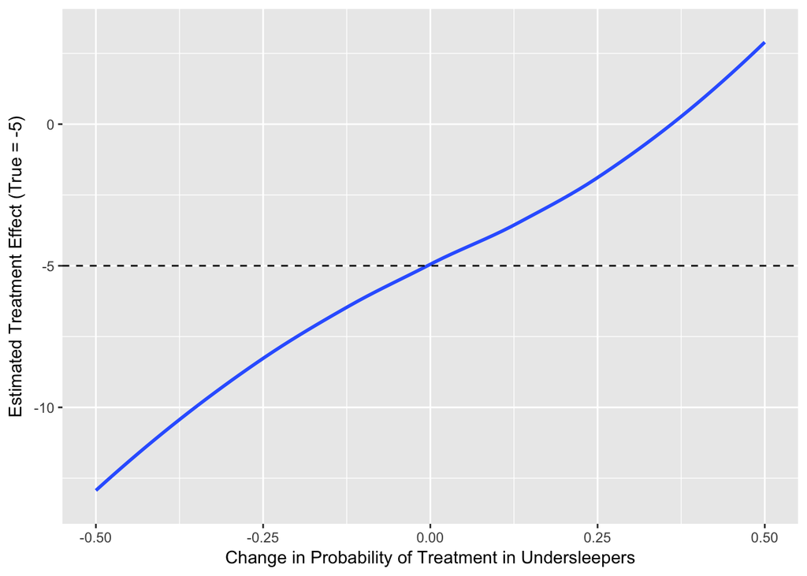

The estimated difference between those who were treated and those who were not treated rapidly deviates from the true value as the probability of seeking treatment shifts from balanced to extremely unbalanced.

This lack of control over assignment and the potential for the non-random assignment to introduce confounding and bias means that when we study treatment effects using observational data we must explicitly address this feature of the data. This is most typically done with epidemiological and observational methods.

## Why

A natural question given the limitation of observational methods relative to randomization-based methods is why/when would we use them? Indeed, the ability of observational methods to support causal inference is not as strong as in a randomized trial; however, frequently we are presented with questions that cannot, either for ethical or logistical, reasons be studied with an randomized design.

Suppose a researcher wanted to study a very rare disease and the effectiveness of a given treatment on the progress of that disease. If there are only 1 case per 100,000, there may be only 3,500 cases in the entire US. Recruitment and followup with such a small potential sample out of 350 million people would prevent a practical randomized study.

Likewise, if the disease has a long latent period. For instance, if a researcher is interested in the effects of an exposure on long-term health over a period of 50 years, the logistical burdens of a randomized design increase rapidly.

More frequently, there are issues with the ethics of conducting a randomized study. For instance, if we have a treatment known to be effective for a disease it is not permitted to give half the patients a placebo.

Often times, either due to these ethical and logistical issues, we are restricted to using observational data where treatment choice is not randomly assigned. However, sometimes the observational data can be useful to provide “real world” evidence of the effect of a treatment or other exposure. While randomized studies have strong internal validity, often the inclusion and exclusion rules used to create a study likely to produce a significant effect with the smallest sample size means that the study population may not be an accurate reflection of the source population. The average treatment effect estimated in an randomized trial may not be a good reflection of the average treatment effect on a randomly selected patient with the disease.

## Major Designs in Epidemiology

All of the study designs in epidemiology attempt to obtain an estimate of the true causal effect of an exposure or treatment in the precense of non-random assignment. The two major designs are cohort and case-control studies while a collection of less common, more purpose drive designs are also used.

### Cohort

A cohort study is focused on recruitment by exposure status and assertaining the disease or outcome status. In this design, enrollees are recruited either by random sampling or by stratification based on exposure status. For instance, subjects may be recruited based on whether they were or were not taking a particular drug and then the outcome is determined.

A cohort study may be done entirely retrospectively - where the outcome is determined and known at the time of the enrollment into the study - or prospectively - where the outcome is not yet realized at the time of enrollment and is discovered during followup, potentially years later.

As a general rule, prospective cohort studies are considered to be a stronger form as the risk of termporal confusion of exposure and disease is lower. Logically, the outcome must occur after the treatment or exposure of interest if the treatment/exposure is to be causally related to the outcome. With retrospective cohort studies, especially if the exposure or date of disease onset ocurred significantly in the past, it may be hard to say which confidence that the exposure/treatment occured before the outcome. In a prospective study, this is less of a threat as the outcome is not yet realized at the time of enrollment.

The extent to which this matters in the context of large secondary claims-based databases is unclear. The data in those databases is recorded prospectively but the outcome is known to the researcher at the time of the analysis. This distiniction matters more in the context of primary data collection and similar studies than when using large secondary data sources.

This framework provides for direct estimation of the relative risk (e.g., the multipliciative difference in the probabilities) between the two exposed and unexposed groups. With the following table:

|  | Diseased | Not Diseased |
| --- | --- | --- |
| Exposed | a | b |
| Not Exposed | c | d |

Additionally, the absolute risk in either group can be calculated. The primary advantage of this design is that the effect estimates may be more directly understandable.

Cohort studies are particularly useful when studying rare exposures. Since the subjects are enrolled on the basis of exposure, it is easy to target potentially rare exposures and build a sufficient sample size. With rare exposures, you get the greatest value for your research budget with cohort studies as you are able to directly focus in on recruiting these subjects.

However, this design is a poor choice for studying rare diseases as a result. As the study recruitment is based on exposure status, it is difficult to recruit a sufficent number of people with the outcome of interest when the outcome is rare. If the outcome only occurs in 1 in 1,000 people in the controls and 5 in 1,000 people in the exposured, it may be difficult to obtain and sufficient sample size to study that outcome within a realatistic research plan.

### Case-Control

Case-control studies are the second major design used in observational studies. In constrast to cohort studies which group on exposure status, case-control studies group based on the outcome. Cases are subjects who have the disease or outcome of interest while controls are subjects who do not. After being grouped on the basis of disease, the levels of exposure in the two groups is compared.

Since recruitment was based on the outcome and not based on the exposure, we can only compare the multiplicative difference in the odds of disease between the two groups. The odds of an event are given by $\frac{p}{1 - p}$.

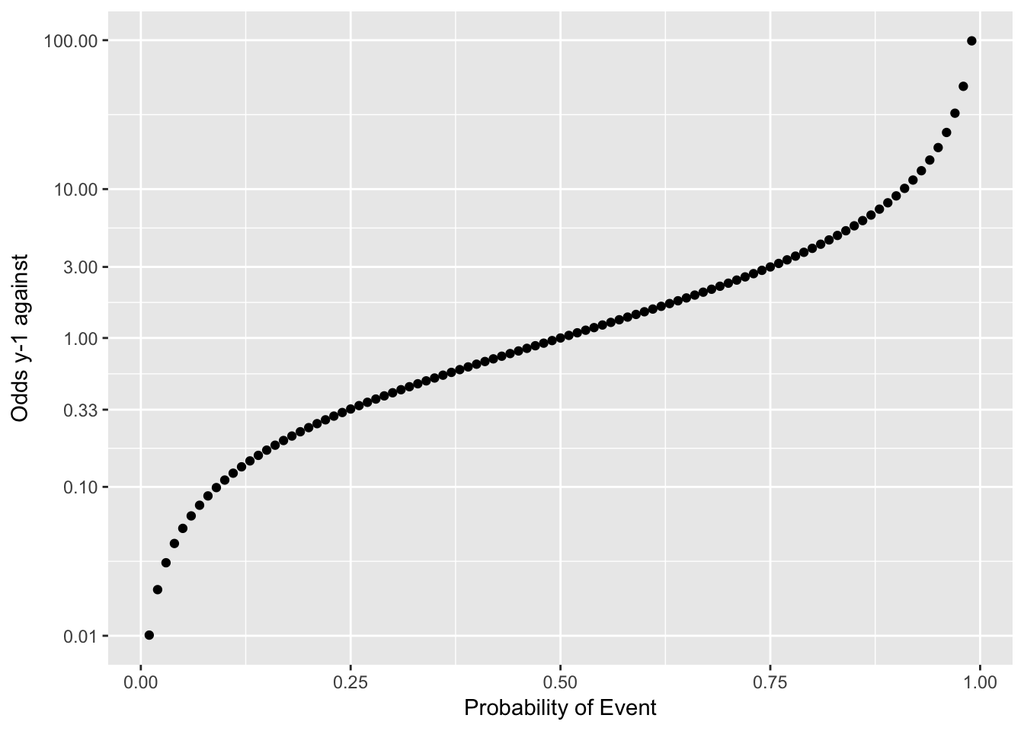

Odds are generally harder to understand that probability for most people. Unfortunately, in the context of case-control studies the measure of association is even more confusing as it is the ratio of the odds or odds ratio (OR).

It is tempting to confuse the relative risk from a cohort study with the odds ratio or discuss the change measured by the odds ratio as a change in risk. However, the value of the odds ratio only relates to the change in odds. This is a subtle, but potentially important, difference.

Whereas cohort studies are well suited to study rare exposure, case-control studies are well suited to study rare diseases and outcomes. Since recruitment is based on outcome, it is easy to start those with a rare condition until a sufficient sample is obtained. However, this strength brings the primary limitation to case-control studies: it is a poor design for the study of a rare exposure. As with cohort studies which required an impossibly large sample size to study a rare disease, case-control studies require a very large sample size to have sufficient power to study a rare exposure.

There is another benefit to using case-control studies to investigate rate diseases - when the disease is rare, the value of the odds ratio converges with the value of the relative risk. This is known as the rare disease assumption.

## Other Common Designs in Epidemiology

### Nested Case-Control

### Case-Crossover

### Case-Time-Control

Pretty sure this is just diff-in-diff

### Cross-Sectional

### Ecological

### Pre/Post

### Interrupted Time Series/Regression Discounity